# tripleEvents plots

Anna Ivanova

11/19/2021

# SETUP

## Supporting functions

### Contrasts (for a df with events+lang+MD conditions)

```r
set_contrasts <- function(dat.stats) {
  # sum (deviation) coding for experiment
  dat.stats$Experiment = factor(dat.stats$Experiment, levels=c('Experiment 2', 'Experiment 1', 'Experiment 3'))
  num_experiments = length(unique(dat.stats$Experiment))
  contrasts(dat.stats$Experiment) = contr.sum(num_experiments)
  colnames(attr(dat.stats$Experiment, 'contrasts')) = c('E2>E3', 'E1>E3')

  # custom coding for effect
  h = hypr(S~N, H~E, 0~0.5*(Sent_Sem+Pic_Sem), (Sent_Sem+Pic_Sem)~(Sent_Perc+Pic_Perc), (Sent_Sem+Sent_Perc)~(Pic_Sem+Pic_Perc), Sent_Sem-Sent_Perc~Pic_Sem-Pic_Perc,    # main
           Sent_Sem~S, (Sent_Sem+Pic_Sem)~(H+E),
           levels=c('Sent_Sem', 'Sent_Perc', 'Pic_Sem', 'Pic_Perc', 'S', 'N', 'H', 'E'))

  contrasts(dat.stats$Effect) = contr.hypothesis(h)
  colnames(attr(dat.stats$Effect, 'contrasts')) = c('S-N', 'H-E', 'TaskSem>Perc', 'StimTypeSent>Pic', 'Task:StimType', 'Sent_Sem>S', 'SemTask>WMTask')

  return(dat.stats)
}
```

### Stats

```r
extract_stats <- function(m, coef_names) {
  model.df = data.frame(coef_names, summary(m)$coefficients[,c(1,2,5)]) %>%
    mutate(ROI=roi)
  names(model.df) = c('Regression Term', 'Beta', 'SE', 'p.value', 'ROI')
  model.df = model.df[,c(5,1,2,3,4)] %>%
    mutate(Beta = round(Beta, 2),
           SE = round(SE, 2),
           p.value = ifelse(p.value>0.001, round(p.value, 3),
                            formatC(p.value, format = "e", digits = 2)))
  return(model.df)
}

correct_FDR <- function(stats_df) {
  stats_df = stats_df %>%
    group_by(`Regression Term`) %>%
    mutate(p.value = p.adjust(p.value, method="fdr")) %>%
    mutate(p.value.FDR = ifelse(p.value>=0.001, as.character(round(p.value, 3)), '<.001')) %>%
    mutate(pLabel = ifelse(p.value<0.001, "***",
                         ifelse(p.value<0.01, "**",
                                ifelse(p.value<0.05, "*", ""))))
  stats_df$p.value = NULL
  return(stats_df)
}
```

### Plot

```r
plot_fROI_responses <- function (df, split_by_expt=FALSE, split_by_ROIgroup=FALSE, include_objectsem=FALSE,
                                 show_legend=TRUE, show_facet_labels=TRUE, ylim=NULL){

if (!include_objectsem) {
  df = df %>% filter(!(Effect %in% c('SEM', 'PERC')))
}

f = ggplot(data=df)+
  stat_summary(mapping=aes(x=ROI, y=EffectSize, fill=Effect),
               geom='col', fun.y='mean', color='black',
               position=position_dodge(preserve="single"), alpha=0.85, width=0.7,
               show.legend = show_legend)+
  stat_summary(mapping=aes(x=ROI, y=EffectSize, group=Effect),
               geom='errorbar', fun.data='mean_se', color='black', position=position_dodge(.7, preserve="single"), size=0.5, width=0)+
  scale_fill_manual(values=c('#B20000', '#FF9999', '#0A730A', '#98CD92',
                             'gray80', 'gray20', '#0000B2', '#B2B2FF', '#D5C33B', '#F4EF3B'))+
  theme_classic()+
  geom_hline(yintercept=0, size=0.5)+
  labs(x=NULL, y='Effect size')+
  theme(axis.text.x = element_text(size=axis_text_size, color='black'),
        axis.title.y = element_text(size=axis_title_size),
        axis.text.y = element_text(size=axis_text_size),
        legend.text = element_text(size=legend_size),
        title = element_text(size=title_size, face='bold'))

if (split_by_expt) {
  f = f + facet_grid(Experiment ~ .)
}
if (split_by_ROIgroup) {
  f = f + ggforce::facet_row(vars(ROIgroup), scales = 'free', space = 'free')
  f = f + theme(strip.text.x = element_text(size=facet_label_size),
                legend.position="bottom")
}
if (!show_facet_labels) {
  f = f + theme(strip.text.y = element_blank())
} else {
  f = f + theme(strip.text.y = element_text(size=facet_label_size))
}
if (!is.null(ylim)) {
  f = f + coord_cartesian(ylim=ylim)
}

return(f)
}
```

# EVENTSALL

## Read and clean data

```r
event_expts = c('EventsOrig_instrsep_2runs', 'events2move_instrsep', 'EventsRev_instrsep')
dat = read_data('events', event_expts)

dat = dat %>%
  mutate(ROI=recode(ROI,
                    '1'='F2', '2'='F1', '3'='TP3', '4'='TP2', '5'='Cer1', '6'='TP4',
                    '7'='F3', '8'='TP1', '9'='O1', '10'='Cer2', '11'='O2'))
dat$ROI = factor(dat$ROI, levels=c('F1','F2','F3','TP1','TP2','TP3','TP4','Cer1','Cer2','O1','O2'))

dat = dat %>%
  mutate(ROIgroup = ifelse(ROI %in% c('Cer1','Cer2'), 'Cerebellum',
                           ifelse(ROI %in% c('F1','F2','F3'), 'Frontal cortex',
                                  ifelse(ROI %in% c('TP1','TP2','TP3','TP4'), 'Temporo-Parietal cortex', 'Occipital cortex'))))
dat$ROIgroup = factor(dat$ROIgroup, levels=c('Frontal cortex', 'Temporo-Parietal cortex', 'Cerebellum', 'Occipital cortex'))
```

## Left-out participants

Some participants were intentionally left out during parcel definition.

```r
left_out_subjects = c('089', '076', '291', '769', '770', '682', '773', '774', '775', '778', '863')
dat = dat %>%
  separate(Subject, c("UID"), extra="drop", sep="_", remove=FALSE) %>%
  mutate(LeftOutSubject = ifelse(UID %in% left_out_subjects, TRUE, FALSE))
```

## Stats

```r
# ignore categorization here
dat.stats = dat %>% filter(!(Effect %in% c('SEM', 'PERC')))
dat.stats$Effect = factor(dat.stats$Effect,
                          levels=c('Sent_Sem', 'Sent_Perc', 'Pic_Sem', 'Pic_Perc', 'S', 'N', 'H', 'E'))
dat.stats$LeftOutSubject = factor(dat.stats$LeftOutSubject,
                                  levels=c('FALSE', 'TRUE'))
```

### Selectivity (all expts together)

```r
dat.stats = set_contrasts(dat.stats)

model = lmer(EffectSize ~ Effect*Experiment + (1|Subject), data=dat.stats, REML=FALSE)
```

```
## fixed-effect model matrix is rank deficient so dropping 2 columns / coefficients
```

```r
coef_names = row.names(coefficients(summary(model)))
```

```r
# Contrast effects in each ROI, FDR-corrected
model.dfs <- list()
index = 1

for (roi in unique(dat$ROI)) {
  dat.roi = dat.stats %>% filter(ROI==roi)
  m = lmer(EffectSize ~ Effect*Experiment + (1|Subject), data=dat.roi, REML=FALSE,
               control = lmerControl(optimizer="bobyqa", optCtrl=list(maxfun=2e5)))
  model.dfs[[index]] <- extract_stats(m, coef_names)
  index = index+1
}
```

[output not shown]

```r
stats_df = do.call("rbind", model.dfs)
# FDR correction
stats_df = correct_FDR(stats_df)

write.table(stats_df, file = "Tables/ROI stats.csv", sep = ",", quote = FALSE, row.names = F)
```

### By experiment (events only)

```r
dat.stats.byexpt =dat %>%
  filter(Effect %in% c('Sent_Sem', 'Sent_Perc', 'Pic_Sem', 'Pic_Perc')) %>%
  separate(Effect, c('StimType', 'Task'), sep="_")
dat.stats.byexpt$StimType = factor(dat.stats.byexpt$StimType, levels=c('Pic', 'Sent'))
dat.stats.byexpt$Task = factor(dat.stats.byexpt$Task, levels=c('Perc', 'Sem'))

model = lmer(EffectSize ~ Task*StimType + (1|Subject), data=dat.stats.byexpt, REML=FALSE)
coef_names = row.names(coefficients(summary(model)))
```

```r
# Contrast effects in each ROI, FDR-corrected

model.dfs <- list()
index = 1

for (expt in unique(dat.stats.byexpt$Experiment)) {
  for (roi in unique(dat.stats.byexpt$ROI)) {
    dat.roi = dat.stats.byexpt %>% filter(ROI==roi, Experiment==expt)
    model = lmer(EffectSize ~ Task*StimType + (1+Task+StimType|Subject), data=dat.roi, REML=FALSE,
                 control = lmerControl(optimizer="bobyqa", optCtrl=list(maxfun=2e5)))
    model.df = data.frame(coef_names,
                          summary(model)$coefficients[,'Estimate'],
                          summary(model)$coefficients[,'Std. Error'],
                          summary(model)$coefficients[,'Pr(>|t|)']) %>%
      mutate(ROI=roi, Experiment=expt)
    names(model.df) = c('Regression Term', 'Beta', 'SE', 'p.value', 'ROI', 'Experiment')
    model.df = model.df[,c(5,6,1,2,3,4)] %>%
      mutate(Beta = round(Beta, 2),
             SE = round(SE, 2),
             p.value = ifelse(p.value>0.001, round(p.value, 3),
                              formatC(p.value, format = "e", digits = 2)))

    model.dfs[[index]] <- model.df
    index = index+1
  }
}
```

[output not shown]

```r
stats_df = do.call("rbind", model.dfs)
# FDR correction
stats_df = correct_FDR(stats_df)

write.table(stats_df, file = "Tables/ROI stats by experiment.csv", sep = ",", quote = FALSE, row.names = F)
```

### Generalization to left-out participants

```r
model = lmer(EffectSize ~ Effect*Experiment + (1|Subject) + (1|ROI), data=dat.stats, REML=FALSE)
```

```
## fixed-effect model matrix is rank deficient so dropping 2 columns / coefficients
```

```r
coef_names = row.names(coefficients(summary(model)))
```

```r
# Contrast effects in each participant group, FDR-corrected

model.dfs <- list()
index = 1

for (group in unique(dat.stats$LeftOutSubject)) {
  dat.group = dat.stats %>% filter(LeftOutSubject==group)
  model = lmer(EffectSize ~ Effect*Experiment + (1|Subject) + (1|ROI), data=dat.group, REML=FALSE,
               control = lmerControl(optimizer="bobyqa", optCtrl=list(maxfun=2e5)))
  model.df = data.frame(coef_names,
                        summary(model)$coefficients[,'Estimate'],
                        summary(model)$coefficients[,'Std. Error'],
                        summary(model)$coefficients[,'Pr(>|t|)']) %>%
    mutate(Group=group)
  names(model.df) = c('Regression Term', 'Beta', 'SE', 'p.value', 'Group')
  model.df = model.df[,c(5,1,2,3,4)] %>%
    mutate(Beta = round(Beta, 2),
           SE = round(SE, 2),
           p.value = ifelse(p.value>0.001, round(p.value, 3),
                            formatC(p.value, format = "e", digits = 2)))

  model.dfs[[index]] <- model.df
  index = index+1
}
```

```
## fixed-effect model matrix is rank deficient so dropping 2 columns / coefficients
## fixed-effect model matrix is rank deficient so dropping 2 columns / coefficients
## fixed-effect model matrix is rank deficient so dropping 2 columns / coefficients
## fixed-effect model matrix is rank deficient so dropping 2 columns / coefficients
```

```r
stats_df = do.call("rbind", model.dfs)
# FDR correction
stats_df = correct_FDR(stats_df)

write.table(stats_df, file = "Tables/Events stats left out participants.csv", sep = ",", quote = FALSE, row.names = F)
```

## Plot

### By ROI group

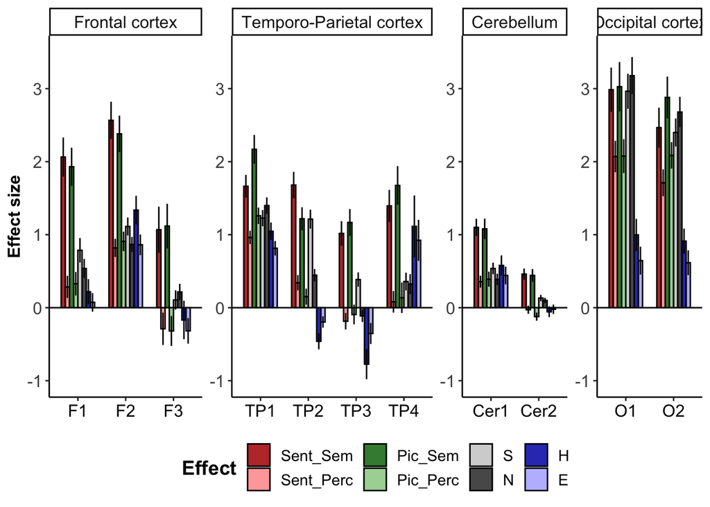

```r
plot_name = 'EventsAll parcels'
plot_fROI_responses(dat, split_by_ROIgroup = TRUE, ylim=c(-1,3.5))
```

```r
ggsave(paste(plot_dir, plot_name,' by ROI group.png',sep=''),
       width=ROI_plot_width+4, height=plot_height_1row+4, units='cm')
```

### By Experiment

```r
dat.mean = dat %>%
  filter(Effect %in% c('Sent_Sem', 'Sent_Perc', 'Pic_Sem', 'Pic_Perc')) %>%
  group_by(Experiment, Subject, Effect) %>%
  summarize(EffectSize = mean(EffectSize)) %>%
  mutate(ROI = "Average")
```

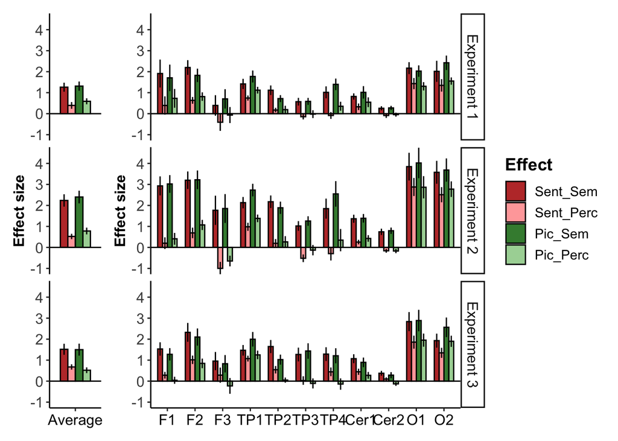

```r
plot_name = 'Events Parcels'

plt.by_expt.mean = plot_fROI_responses(dat.mean, split_by_expt=TRUE, show_legend=FALSE, show_facet_labels=FALSE, ylim=c(-1,4.5))
plt.by_expt.ROI = plot_fROI_responses(dat %>% filter(Effect %in% c('Sent_Sem', 'Sent_Perc', 'Pic_Sem', 'Pic_Perc')), split_by_expt=TRUE, ylim=c(-1,4.5))
plt.by_expt.mean + plt.by_expt.ROI + plot_layout(widths=c(1,6))
```

```r
ggsave(paste(plot_dir, plot_name,' by expt.png',sep=''),
       width=ROI_plot_width+4, height=plot_height_3rows, units='cm')
```

### Generalization to left-out participants

```r
dat.mean = dat %>%
  group_by(Experiment, Subject, Effect, LeftOutSubject) %>%
  summarize(EffectSize = mean(EffectSize)) %>%
  mutate(ROI=ifelse(LeftOutSubject, 'Group2 (n=9)', 'Group1 (n=30)'))
```

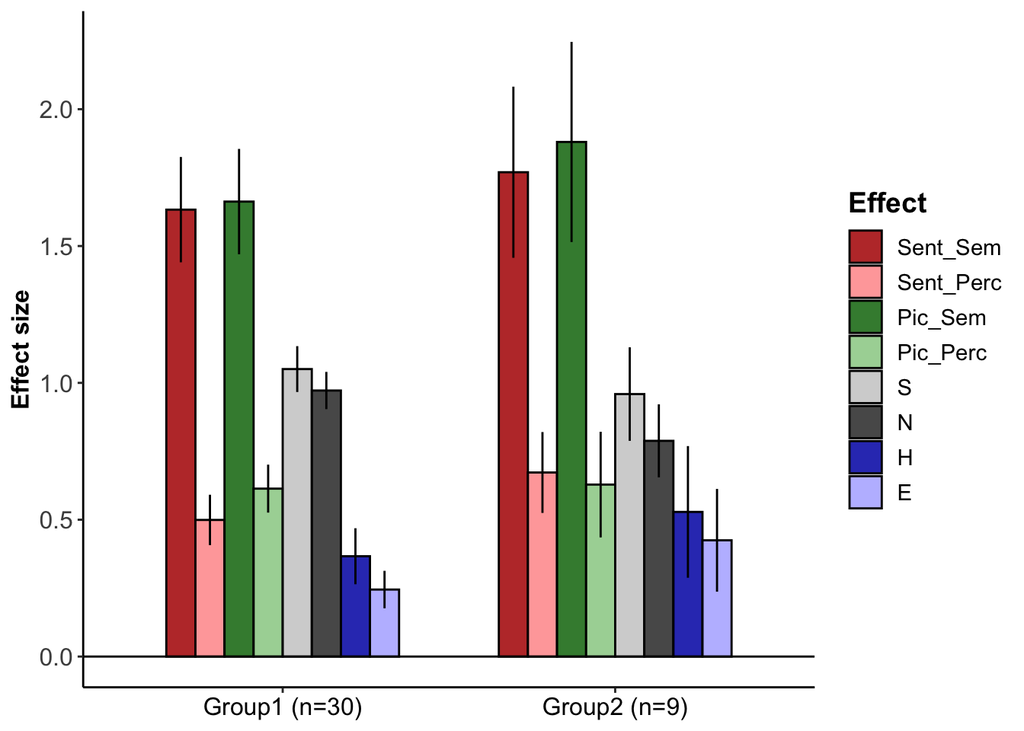

```r
plot_name = 'Events Parcels - Left-out subjects'
plot_fROI_responses(dat.mean)
```

```r
ggsave(paste(plot_dir,plot_name,'.png',sep=''),
       width=hemi_plot_width, height=plot_height_1row, units='cm')
```

# LANG

## Read data

```r
lang_expts = c('SWNlocIPS168_3runs', 'langlocSN', 'langlocSN')
dat = read_data('language', lang_expts)

# clean
dat = dat %>%
  mutate(Hemisphere = ifelse(ROI %in% c(1,2,3,4,5,6), 'LH', 'RH')) %>%
  mutate(ROI = recode(dat$ROI,
        '1'='LIFG_orb', '2'='LIFG', '3'='LMFG',
        '4'='LAntTemp', '5'='LPostTemp', '6'='LAngG',
        '7'='RIFG_orb', '8'='RIFG', '9'='RMFG',
        '10'='RAntTemp', '11'='RPostTemp', '12'='RAngG'))
dat$ROI = factor(dat$ROI, levels=c('LIFG_orb', 'LIFG', 'LMFG', 'LAntTemp', 'LPostTemp', 'LAngG',
                                   'RIFG_orb', 'RIFG', 'RMFG','RAntTemp', 'RPostTemp', 'RAngG'))

# split by hemi
dat.lh = dat %>% filter(Hemisphere=='LH')
dat.rh = dat %>% filter(Hemisphere=='RH')
```

## Stats

```r
dat.stats = dat %>% filter(!(Effect %in% c('SEM', 'PERC')))
dat.stats$Effect = factor(dat.stats$Effect,
                          levels=c('Sent_Sem', 'Sent_Perc', 'Pic_Sem', 'Pic_Perc', 'S', 'N', 'H', 'E'))
```

### Selectivity (all expts together)

```r
dat.stats = set_contrasts(dat.stats)

m = lmer(EffectSize ~ Effect*Experiment*Hemisphere + (1|Subject) + (1|ROI), data=dat.stats, REML=FALSE)
```

```
## fixed-effect model matrix is rank deficient so dropping 4 columns / coefficients
```

```r
summary(m)
```

```
## Linear mixed model fit by maximum likelihood . t-tests use Satterthwaite's
##   method [lmerModLmerTest]
## Formula: EffectSize ~ Effect * Experiment * Hemisphere + (1 | Subject) +
##     (1 | ROI)
##    Data: dat.stats
##
##      AIC      BIC   logLik deviance df.resid
##  14586.5  14895.8  -7246.2  14492.5     5281
##
## Scaled residuals:
##     Min      1Q  Median      3Q     Max
## -3.6979 -0.5706 -0.0486  0.4765  8.7399
##
## Random effects:
##  Groups   Name        Variance Std.Dev.
##  Subject  (Intercept) 0.1146   0.3385
##  ROI      (Intercept) 0.1536   0.3919
##  Residual             0.8612   0.9280
## Number of obs: 5328, groups:  Subject, 42; ROI, 12
##
## Fixed effects:
##                                                       Estimate Std. Error
## (Intercept)                                          1.194e+00  1.730e-01
## EffectS-N                                            1.276e+00  6.970e-02
## EffectH-E                                           -2.337e-01  7.160e-02
## EffectTaskSem>Perc                                   1.600e+00  1.123e-01
## EffectStimTypeSent>Pic                               6.264e-01  1.123e-01
## EffectTask:StimType                                  4.565e-01  1.123e-01
## EffectSent_Sem>S                                    -2.275e-01  7.488e-02
## EffectSemTask>WMTask                                 3.090e+00  1.165e-01
## ExperimentE2>E3                                      3.440e-01  6.946e-02
## ExperimentE1>E3                                     -4.240e-01  9.760e-02
## HemisphereRH                                        -4.801e-01  2.331e-01
## EffectS-N:ExperimentE2>E3                            2.161e-01  9.032e-02
## EffectH-E:ExperimentE2>E3                            2.749e-16  7.160e-02
## EffectTaskSem>Perc:ExperimentE2>E3                   3.766e-01  1.593e-01
## EffectStimTypeSent>Pic:ExperimentE2>E3              -4.379e-02  1.593e-01
## EffectTask:StimType:ExperimentE2>E3                  3.547e-02  1.593e-01
## EffectSent_Sem>S:ExperimentE2>E3                     4.838e-02  1.030e-01
## EffectSemTask>WMTask:ExperimentE2>E3                 2.640e-01  1.179e-01
```

[output cut: 103 more lines]

```
## ExperimentE1>E3:HemisphereRH
## EffectS-N:ExperimentE2>E3:HemisphereRH
## EffectH-E:ExperimentE2>E3:HemisphereRH
## EffectTaskSem>Perc:ExperimentE2>E3:HemisphereRH     .
## EffectStimTypeSent>Pic:ExperimentE2>E3:HemisphereRH
## EffectTask:StimType:ExperimentE2>E3:HemisphereRH
## EffectSent_Sem>S:ExperimentE2>E3:HemisphereRH
## EffectSemTask>WMTask:ExperimentE2>E3:HemisphereRH
## EffectS-N:ExperimentE1>E3:HemisphereRH
## EffectTaskSem>Perc:ExperimentE1>E3:HemisphereRH
## EffectStimTypeSent>Pic:ExperimentE1>E3:HemisphereRH
## EffectTask:StimType:ExperimentE1>E3:HemisphereRH
## EffectSent_Sem>S:ExperimentE1>E3:HemisphereRH       .
## ---
## Signif. codes:  0 '***' 0.001 '**' 0.01 '*' 0.05 '.' 0.1 ' ' 1
```

```
##
## Correlation matrix not shown by default, as p = 44 > 12.
## Use print(x, correlation=TRUE)  or
##     vcov(x)        if you need it
```

```
## fit warnings:
## fixed-effect model matrix is rank deficient so dropping 4 columns / coefficients
```

As expected, response to sentence reading was stronger than to nonword reading ($\beta$=1.28, SE=0.07, p=0). For the critical experiments, there was a strong effect of task (semantic > perceptual; $\beta$=1.6, SE=0.11, p=0), stimulus type (sentences > pictures; $\beta$=0.63, SE=0.11, p=0), and an interaction between task type and stimulus type ($\beta$=0.46, SE=0.11, p=0), indicating a preference for sentences during the semantic task. These results are consistent with those reported in Ivanova et al (2021), who analyzed a subset of these data (specifically, Experiment 3).

```r
# Contrast effects in each ROI, FDR-corrected
model = lmer(EffectSize ~ Effect*Experiment + (1|Subject), data=dat.stats, REML=FALSE)
```

```
## fixed-effect model matrix is rank deficient so dropping 2 columns / coefficients
```

```r
coef_names = row.names(coefficients(summary(model)))

model.dfs <- list()
index = 1

for (roi in unique(dat$ROI)) {
  dat.roi = dat.stats %>% filter(ROI==roi)
  model = lmer(EffectSize ~ Effect*Experiment + (1|Subject), data=dat.roi, REML=FALSE,
               control = lmerControl(optimizer="bobyqa", optCtrl=list(maxfun=2e5)))
  model.dfs[[index]] <- extract_stats(model, coef_names)
  index = index+1
}
```

[output not shown]

```r
stats_df = do.call("rbind", model.dfs)
# FDR correction
stats_df = correct_FDR(stats_df)

write.table(stats_df, file = "Tables/language ROI stats.csv", sep = ",", quote = FALSE, row.names = F)
```

### By experiment (events only)

```r
dat.stats.byexpt =dat %>%
  filter(Effect %in% c('Sent_Sem', 'Sent_Perc', 'Pic_Sem', 'Pic_Perc')) %>%
  separate(Effect, c('StimType', 'Task'), sep="_")
dat.stats.byexpt$StimType = factor(dat.stats.byexpt$StimType, levels=c('Pic', 'Sent'))
dat.stats.byexpt$Task = factor(dat.stats.byexpt$Task, levels=c('Perc', 'Sem'))

model = lmer(EffectSize ~ Task*StimType + (1|Subject), data=dat.stats.byexpt, REML=FALSE)
coef_names = row.names(coefficients(summary(model)))
```

## Plot

### Mean hemisphere

```r
dat.mean <- dat %>%
  group_by(Effect, Subject, Experiment, Hemisphere) %>%
  summarize(EffectSize = mean(EffectSize)) %>%
  mutate(ROI=Hemisphere)
```

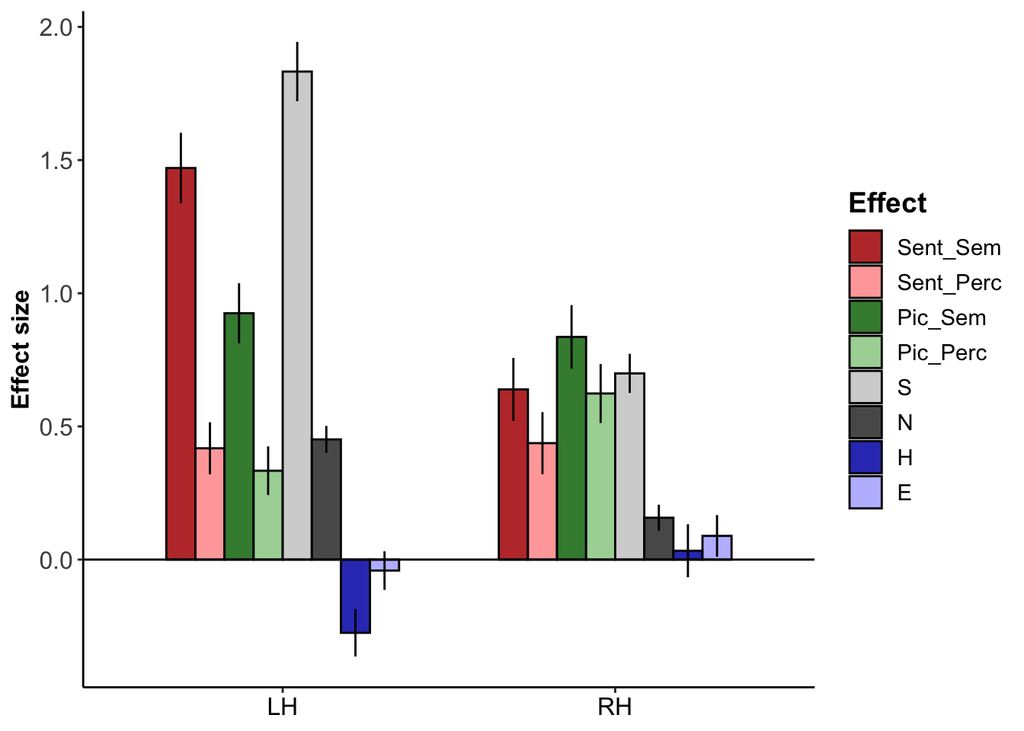

```r
plot_name = 'Language Network'
plot_fROI_responses(dat.mean)
```

```r
ggsave(paste('plots/',plot_name,'_hemi.png',sep=''),
       width=hemi_plot_width, height=plot_height_1row, units='cm')
```

### ROIs by hemisphere

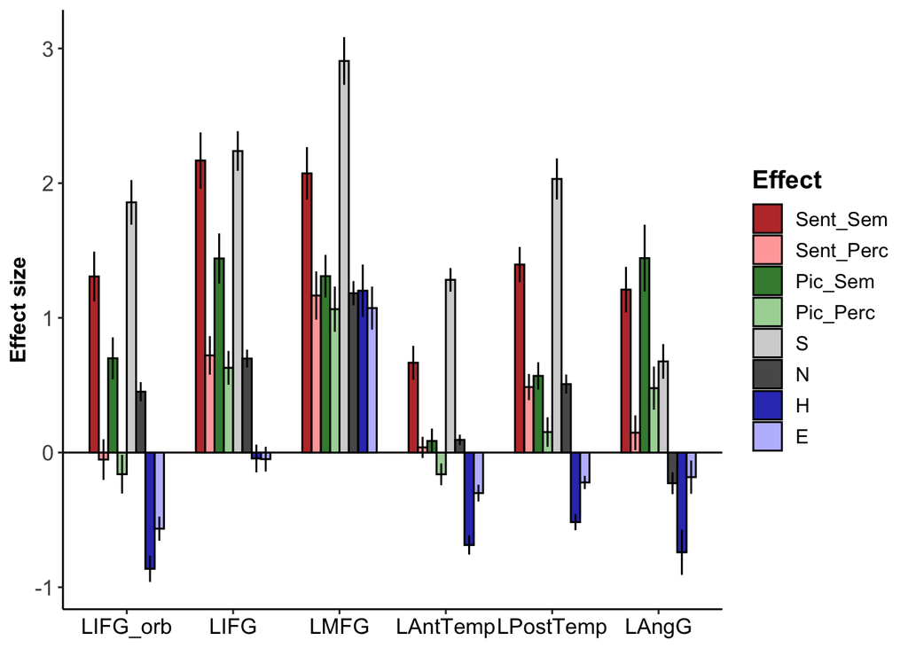

```r
plot_name = 'Language Network - LH'
plot_fROI_responses(dat.lh)
```

```r
ggsave(paste('plots/',plot_name,'_ROI.png',sep=''),
       width=ROI_plot_width, height=plot_height_1row, units='cm')
```

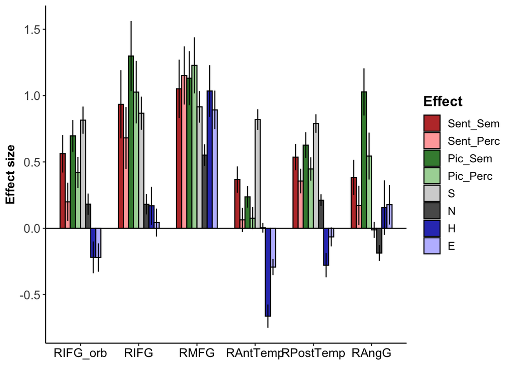

```r
plot_name = 'Language Network - RH'
plot_fROI_responses(dat.rh)
```

```r
ggsave(paste('plots/',plot_name,'_ROI.png',sep=''),
       width=ROI_plot_width, height=plot_height_1row, units='cm')
```

# MD

## Read data

```r
MD_expts = c('NONE', 'spatialFIN', 'spatialFIN')
dat = read_data('MD', MD_expts)

# split by hemi
dat = dat %>% separate(ROI, c("Hemisphere", NA), remove=FALSE)
dat.lh = dat %>% filter(Hemisphere=='LH')
dat.rh = dat %>% filter(Hemisphere=='RH')
```

## Plot

### Mean hemisphere

```r
dat.mean <- dat %>%
  group_by(Effect, Subject, Experiment, Hemisphere) %>%
  summarize(EffectSize = mean(EffectSize)) %>%
  mutate(ROI=Hemisphere)
```

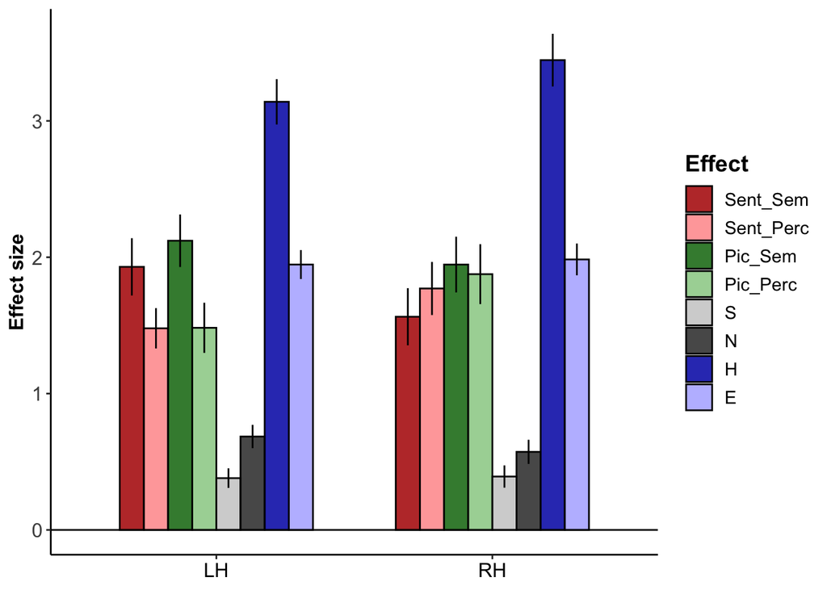

```r
plot_name = 'MD Network'
plot_fROI_responses(dat.mean)
```

```r
ggsave(paste('plots/',plot_name,'_hemi.png',sep=''),
       width=hemi_plot_width, height=plot_height_1row, units='cm')
```

### ROIs by hemisphere

[figure not shown]

```r
plot_name = 'MD Network - LH'
plot_fROI_responses(dat.lh)
```

```r
ggsave(paste('plots/',plot_name,'_ROI.png',sep=''),
       width=ROI_plot_width, height=plot_height_1row, units='cm')
```

[figure not shown]

```r
plot_name = 'MD Network - RH'
plot_fROI_responses(dat.rh)
```

```r
ggsave(paste('plots/',plot_name,'_ROI.png',sep=''),
       width=ROI_plot_width, height=plot_height_1row, units='cm')
```

# DMN

## Read data

```r
DMN_expts = c('NONE', 'spatialFIN', 'spatialFIN')
dat = read_data('DMN', DMN_expts)

dat = dat %>%
  mutate(Hemisphere = ifelse(ROI %in% c(1,2,3,4,5,6), 'LH', 'RH')) %>%
  mutate(ROI = recode(dat$ROI,
        '1'='LH_FrontalMed', '2'='LH_PostCing', '3'='LH_TPJ',
        '4'='LH_MidCing', '5'='LH_STGorInsula', '6'='LH_AntTemp',
        '7'='RH_FrontalMed', '8'='RH_PostCing', '9'='RH_TPJ',
        '10'='RH_MidCing', '11'='RH_STGorInsula', '12'='RH_AntTemp'))

# split by hemi
dat.lh = dat %>% filter(Hemisphere=='LH')
dat.rh = dat %>% filter(Hemisphere=='RH')
```

## Plot

### Mean hemisphere

```r
dat.mean <- dat %>%
  group_by(Effect, Subject, Experiment, Hemisphere) %>%
  summarize(EffectSize = mean(EffectSize)) %>%
  mutate(ROI=Hemisphere)
```

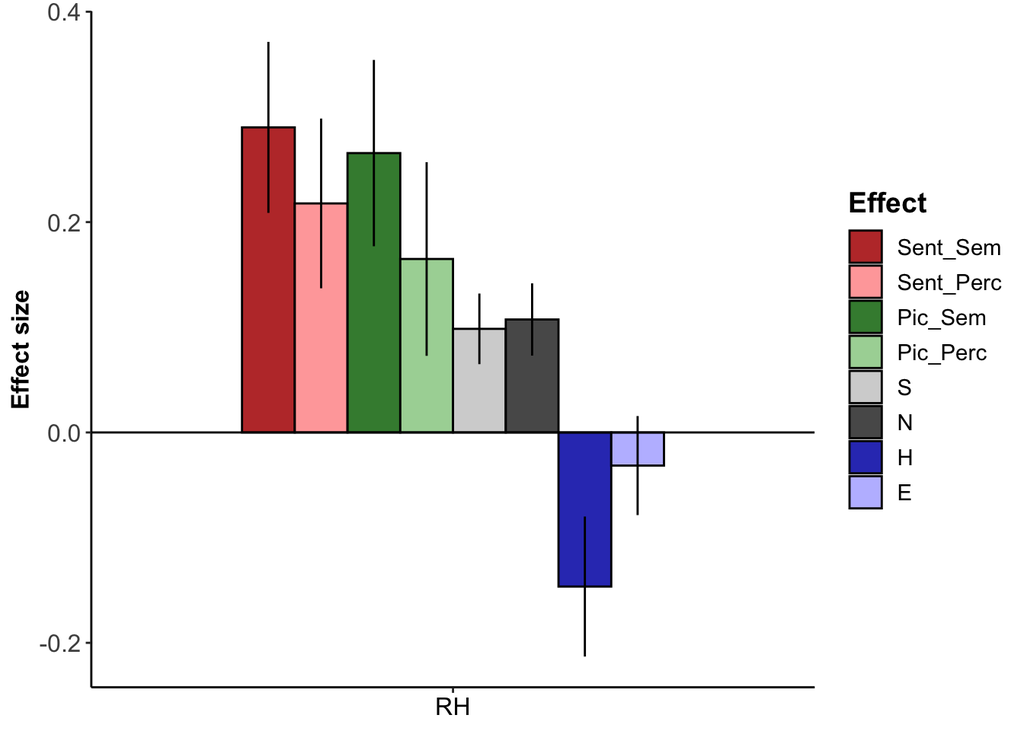

```r
plot_name = 'Default Mode Network'
plot_fROI_responses(dat.mean)
```

```r
ggsave(paste('plots/',plot_name,'_hemi.png',sep=''),
       width=hemi_plot_width, height=plot_height_1row, units='cm')
```

### ROIs by hemisphere

[figure not shown]

```r
plot_name = 'Default Mode Network - LH'
plot_fROI_responses(dat.lh)
```

```r
ggsave(paste('plots/',plot_name,'_ROI.png',sep=''),
       width=ROI_plot_width, height=plot_height_1row, units='cm')
```

[figure not shown]

```r
plot_name = 'Default Mode Network - RH'
plot_fROI_responses(dat.rh)
```

```r
ggsave(paste('plots/',plot_name,'_ROI.png',sep=''),
       width=ROI_plot_width, height=plot_height_1row, units='cm')
```